# Analysis of Sediment Toxicity Data : Pesticides

## Applying to the DDT Residues data

Note the use of “mutate” after the group_by() so that the dataframe is not collapsed to the grouping variables, as it would be by summary().

The calculations involved are random, so if you want to get exactly the same results, you need to set the random number seed with set.seed()

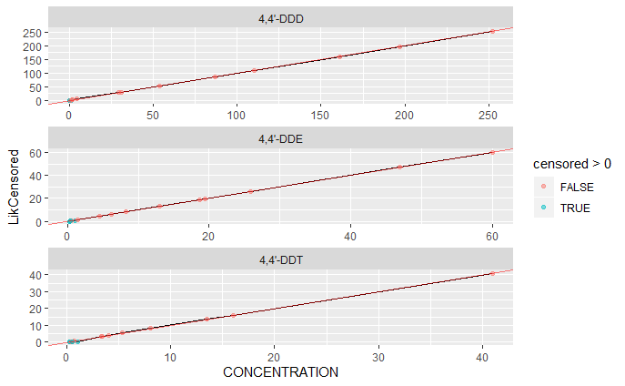

```r
dat2 <- Pesticides.data.long %>%
  filter(PARAMETER_NAME %in% c("4,4'-DDD", "4,4'-DDE", "4,4'-DDT")) %>%
  group_by(PARAMETER_NAME) %>%
  mutate(LikCensored = SemiSimulatedLN(CONCENTRATION, censored>0)) %>%
  mutate(HalfDL = ifelse(censored>0, CONCENTRATION/2, CONCENTRATION)) %>%
  ungroup()

ggplot(dat2, aes(CONCENTRATION,LikCensored)) + geom_line() + geom_point(aes(color = censored>0), alpha = 0.5) +
  geom_abline(intercept = 0, slope= 1, alpha = 0.5, color = 'red') +
facet_wrap('PARAMETER_NAME', scales = 'free', nrow=3)
```

```r
res2 <- dat2 %>%
  group_by(SAMPLE_ID) %>%
  summarize(LNtotPesticide = sum(LikCensored),
            halfDLtotPesticide = sum(HalfDL),
            totPesticide = sum(CONCENTRATION))
```

So, for these parameters, the impact of using maximum likelihood estimated is very small.

[figure not shown]

```r
ggplot(res2, aes(x=totPesticide))+
  geom_point(aes(y=LNtotPesticide), color = 'orange') +
  geom_text(aes(y=LNtotPesticide, label = SAMPLE_ID), color = 'orange', hjust = 0) +
  geom_point(aes(y=halfDLtotPesticide), color = 'red') +
  geom_abline(intercept = 0, slope = 1, lty = 2) +
  geom_text(aes(x=200, y=210, label = '1:1 Line'), angle = 35) +
  geom_hline(yintercept = 1.58, color = 'blue', lty=3, size=1) +    #ERL
  geom_text(aes(x=250, y=10, label = 'ERL'), color = 'blue') +
  geom_hline(yintercept = 46.1, color = 'blue', lty=3, size=1) +     #ERM
  geom_text(aes(x=250, y=60, label = 'ERM'), color = 'blue') +
  xlab('Total, Assuming Detection Limit') +
  xlim(c(0,375)) +
  scale_x_log10() + scale_y_log10() +
  theme_minimal()
```

So, results are similar, except for CSP-6 and CSP-15, where the choice of estimator affects whether you determine that the likely levels of DDT residues exceeds ERL.

# Conclusion

We should present results of pesticides restricted only to the sum of the DDT breakdown products. I am uncertain how to label that item in a graphic.

#Correcting for Half non-detects DDT samples from CSS-15 consisted of one non-detect and one elevated observation. it’s not obvious how to handle this site, as the two samples were sufficiently different to fail as a QA/QC check. Here we report the average of the two values, which presents some problems addressing the non-detect correctly.

When we average across the two values, we are averaging a non-detect with a significantly higher observation. In the preceeding analysis, we flagged the average as a censored value, below the average. That may bias the value for certain analyses.

In our preliminary analyses (above), we saw that pesticide levels for CSS-15 were relatively low. If you replace the ND with the “detection limit” – which here would be an average of the observed concentration and the DL – that value slightly exceeds ERL. Using either half the DL or maximum likelihood estimation, the sample lies below ERL.

So. how we handle this split sample matters.

To be thorough, we need to calculate our censored estimates (ND, Half ND and Maximum Likelihood) on the original raw data and average the results, rather than just assume everything works out o.k. when applied to the avergaged value.

Obviously,if we are looking at the full detection limit, the average of a sum is the sum of the averages, and it makes no difference, but it should matter for the other two estimators, especially for the maximum liklihood estimator.

### Raw Observations

```r
the.data %>%
  filter(PARAMETER_NAME=="4,4'-DDT") %>%
  filter(SAMPLE_ID == 'CSS-15') %>%
  filter(is.na(`%_RECOVERY`)) %>%
  filter(SAMPLE_ID != 'QC')
```

| SAMPLE_ID | CAS_NO | PARAMETER_NAME | CONCENTRATION | LAB_QUALIFIER | REPORTING_LIMIT | PARAMETER_UNITS | %_RECOVERY | RPD | TEST | PARAMETER_QUALIFIER | PARAMETER_FILTERED | MDL | DILUTION_FACTOR |
| --- | --- | --- | --- | --- | --- | --- | --- | --- | --- | --- | --- | --- | --- |
| CSS-15 | 50293 | 4,4'-DDT | 0.744 | P | 0.366 | UG/KG | NA | NA | SW8081B | 2C | NA | 0.366 | 1 |
| CSS-15 | 50293 | 4,4'-DDT | NA | U | 0.382 | UG/KG | NA | NA | SW8081B | 2C | NA | 0.382 | 1 |

## So, correct values

```r
(0.744 +0.382)/2
```

```
[1] 0.563
```

```r
(0.744 + (0.382/2))/2
```

```
[1] 0.4675
```

### Calculate half DL limits both ways

```r
tmp <- the.data %>%
  filter(PARAMETER_NAME=="4,4'-DDT") %>%
  filter(SAMPLE_ID == 'CSS-15') %>%
  filter(is.na(`%_RECOVERY`)) %>%
  filter(SAMPLE_ID != 'QC') %>%
  mutate(censored = LAB_QUALIFIER %in% c('U', 'J')) %>%
  mutate(CONCENTRATION = ifelse(censored, REPORTING_LIMIT, CONCENTRATION)) %>%
  select(censored, CONCENTRATION, REPORTING_LIMIT) %>%
  mutate(halfdl = ifelse(censored, REPORTING_LIMIT/2, CONCENTRATION))
mean(tmp%>%pull(CONCENTRATION))/2
```

```
[1] 0.2815
```

```r
mean(tmp%>%pull(halfdl))
```

```
[1] 0.4675
```

So, doing this right sharply increases our estimate.

### Calculate Maximum Likelihood Estimator two ways

First the correct way, by averaging the two estimates

```r
est <- the.data %>%
  filter(PARAMETER_NAME=="4,4'-DDT") %>%
  filter(is.na(`%_RECOVERY`)) %>%
  filter(SAMPLE_ID != 'QC') %>%
  select(SAMPLE_ID, CONCENTRATION, REPORTING_LIMIT, LAB_QUALIFIER) %>%
  mutate(censored = LAB_QUALIFIER %in% c('U', 'J')) %>%
  mutate(CONCENTRATION = ifelse(censored, REPORTING_LIMIT, CONCENTRATION)) %>%
  mutate(lnest = SemiSimulatedLN(CONCENTRATION, censored)) %>%
  filter(SAMPLE_ID == 'CSS-15') %>%
  pull(lnest)
est
```

```
[1] 0.744000 0.144128
```

```r
mean(est)
```

```
[1] 0.444064
```

Second, the simple way, by calculating estimates based on average value.

```r
Pesticides.data.long %>%
  filter(PARAMETER_NAME=="4,4'-DDT") %>%
  mutate(lnest = SemiSimulatedLN(CONCENTRATION, censored)) %>%
  filter(SAMPLE_ID == 'CSS-15') %>%
  pull(lnest)
```

```
[1] 0.1983169
```